# Movies Data Cleaning & Data Join

Team A - Sergi Abashidze, Camila Barbagallo, Paula García Serrano, Rocío González Lantero

17/11/2020

```r
library(lubridate)
library(stringr)
library(textclean)
library(plyr)
library(dplyr)
```

```r
tags <- read.csv(file="tags.csv", header = TRUE, stringsAsFactors = F)
genomescores <- read.csv(file="genome-scores.csv", header = TRUE, stringsAsFactors = F)
ratings <- read.csv(file="ratings.csv", header = TRUE, stringsAsFactors = F)
movies <- read.csv(file="movies.csv", header = TRUE, stringsAsFactors = F)
links <- read.csv(file="links.csv", header = TRUE, stringsAsFactors = F)
```

# 1. First inspection of datasets

## 1.1 Tags

```r
head(tags)
```

```
##   userId movieId          tag  timestamp
## 1     14     110         epic 1443148538
## 2     14     110     Medieval 1443148532
## 3     14     260       sci-fi 1442169410
## 4     14     260 space action 1442169421
## 5     14     318 imdb top 250 1442615195
## 6     14     318      justice 1442615192
```

## 1.2 Genomescores

```r
head(genomescores)
```

```
##   movieId tagId relevance
## 1       1     1   0.02900
## 2       1     2   0.02375
## 3       1     3   0.05425
## 4       1     4   0.06875
## 5       1     5   0.16000
## 6       1     6   0.19525
```

## 1.3 Ratings

```r
head(ratings)
```

```
##   userId movieId rating timestamp
## 1      1       1      4 964982703
## 2      1       3      4 964981247
## 3      1       6      4 964982224
## 4      1      47      5 964983815
## 5      1      50      5 964982931
## 6      1      70      3 964982400
```

## 1.4 Movies

```r
head(movies)
```

```
##   movieId                              title
## 1       1                   Toy Story (1995)
## 2       2                     Jumanji (1995)
## 3       3            Grumpier Old Men (1995)
## 4       4           Waiting to Exhale (1995)
## 5       5 Father of the Bride Part II (1995)
## 6       6                        Heat (1995)
##                                        genres
## 1 Adventure|Animation|Children|Comedy|Fantasy
## 2                  Adventure|Children|Fantasy
## 3                              Comedy|Romance
## 4                        Comedy|Drama|Romance
## 5                                      Comedy
## 6                       Action|Crime|Thriller
```

## 1.5 Links

```r
head(links)
```

```
##   movieId imdbId tmdbId
## 1       1 114709    862
## 2       2 113497   8844
## 3       3 113228  15602
## 4       4 114885  31357
## 5       5 113041  11862
## 6       6 113277    949
```

# 2. Preprocessing

## 2.1 Genomescores

For the genomescores dataset, we have noticed that it could be a good option if we only care about those tags whose relevance is above 50%. Therefore, we are performing this selection inside a new dataset: genomescores_clean.

```r
drop_tags <- function (data,relevance) {
   wanted<- data$relevance > 0.5
   data[wanted, , drop = FALSE]
}
```

```r
genomescores_clean <- drop_tags(genomescores, relevance)
```

## 2.2 Movies

In the movies dataset the title variable is not really useful, since we are not performing any NLP techniques and, as an identifier for the movies, we have the movieId. Therefore, we will drop it.

```r
movies$title <- NULL
```

## 2.3 Ratings

From the ratings dataset, we have noticed that the timestamp is different from that on the tags dataset. Therefore, we are renaming it to avoid confusion.

```r
names(ratings)[4] <- "ts_ratings"
```

Furthermore, we will translate the timestamps from unix format and we will split the data to have a date column (date_ratings) and a time column (time_ratings).

```r
ratings$ts_ratings <- lubridate::as_datetime(ratings$ts_ratings)
#Dividing time and date
ratings$date_ratings <- as.Date(sapply(strsplit(as.character(ratings$ts_ratings), " "), "[", 1))
ratings$time_ratings <- sapply(strsplit(as.character(ratings$ts_ratings), " "), "[", 2)
# Remove the one with everything
ratings$ts_ratings <- NULL
```

## 2.4 Tags

From the tags column, we have noticed that the timestamp is different from that on the ratings dataset. Therefore, we are renaming it to avoid confusion.

```r
names(tags)[4] <- "ts_tags"
```

Additionally, we will perform basic cleaning on the tag column following these steps:

1. Lowercase all the words
2. Remove unnecessary white spaces, so the data looks consistent
3. Remove non-ascii characters
4. Delete unnecessary letters that are repeated
5. Remove punctuation

```r
clean_tags_text <- function(df_and_column){

  # 1
  df_and_column <- tolower(df_and_column)
  # 2
  df_and_column <- str_trim(df_and_column)
  # 3
  df_and_column <- replace_non_ascii(df_and_column)
  # 4
  df_and_column <- replace_word_elongation(df_and_column)
  # 5
  df_and_column <- gsub('[[:punct:] ]+',' ',df_and_column)

  return(df_and_column)
}
```

```r
tags$tag <- clean_tags_text(tags$tag)
```

Further than this, we will translate the timestamps from unix format and we will split the data to have a date column (date_tags) and a time column (time_tags).

```r
tags$ts_tags <- lubridate::as_datetime(tags$ts_tags)
# Dividing time and date
tags$date_tags <- as.Date(sapply(strsplit(as.character(tags$ts_tags), " "), "[", 1))
tags$time_tags <- sapply(strsplit(as.character(tags$ts_tags), " "), "[", 2)
# Remove the one with everything
tags$ts_tags <- NULL
```

# 3. Join

Regarding the join strategy, we merged the ratings and the tags datasets based on both movieId and userId. Once we performed this, we merged it with the other datasets based on movieId.

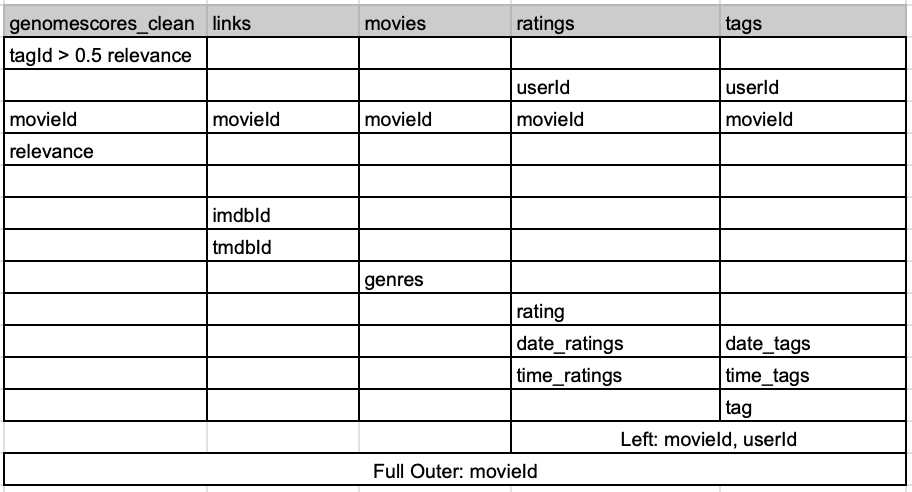

Join Strategy

## 3.1 Join: ratings + tags

```r
join1 <- left_join(ratings, tags, by=c('movieId', 'userId'))
head(join1)
```

```
##   userId movieId rating date_ratings time_ratings  tag date_tags time_tags
## 1      1       1      4   2000-07-30     18:45:03 <NA>      <NA>      <NA>
## 2      1       3      4   2000-07-30     18:20:47 <NA>      <NA>      <NA>
## 3      1       6      4   2000-07-30     18:37:04 <NA>      <NA>      <NA>
## 4      1      47      5   2000-07-30     19:03:35 <NA>      <NA>      <NA>
## 5      1      50      5   2000-07-30     18:48:51 <NA>      <NA>      <NA>
## 6      1      70      3   2000-07-30     18:40:00 <NA>      <NA>      <NA>
```

## 3.2 Join: previous join + genomescores_clean + links + movies

```r
join2 <- full_join(join1, genomescores_clean, by='movieId')
join3 <- full_join(join2, links, by='movieId')
join4 <- full_join(join3, movies, by='movieId')
```

```r
head(join4)
```

```
##   userId movieId rating date_ratings time_ratings  tag date_tags time_tags
## 1      1       1      4   2000-07-30     18:45:03 <NA>      <NA>      <NA>
## 2      1       1      4   2000-07-30     18:45:03 <NA>      <NA>      <NA>
## 3      1       1      4   2000-07-30     18:45:03 <NA>      <NA>      <NA>
## 4      1       1      4   2000-07-30     18:45:03 <NA>      <NA>      <NA>
## 5      1       1      4   2000-07-30     18:45:03 <NA>      <NA>      <NA>
## 6      1       1      4   2000-07-30     18:45:03 <NA>      <NA>      <NA>
##   tagId relevance imdbId tmdbId                                      genres
## 1    11   0.58700 114709    862 Adventure|Animation|Children|Comedy|Fantasy
## 2    19   0.66825 114709    862 Adventure|Animation|Children|Comedy|Fantasy
## 3    29   0.90700 114709    862 Adventure|Animation|Children|Comedy|Fantasy
## 4    30   0.60850 114709    862 Adventure|Animation|Children|Comedy|Fantasy
## 5    61   0.59575 114709    862 Adventure|Animation|Children|Comedy|Fantasy
## 6    62   0.66025 114709    862 Adventure|Animation|Children|Comedy|Fantasy
```

```r
write.csv(join4,"Joined.csv", row.names = FALSE)
```